# prak67

2023-10-16

## Packages

```r
library(ggplot2)
library(tsibble)
library(tseries)
library(MASS)
library(forecast)
library(TSA)
library(TTR)
library(aTSA)
library(graphics)
library(rio)
```

## Data

```r
data <-import("https://raw.githubusercontent.com/akabanenabaka/mpdw/main/Jumlah%20Perusahaan%20Transaksi%20dan%20Indeks%20Saham%20di%20Bursa%20Efek.csv")
dataa <- ts(data$Yt)
dataa
```

```
## Time Series:
## Start = 1
## End = 115
## Frequency = 1
##   [1] 488 488 489 493 494 496 501 501 501 501 501 506 506 506 507 507 510 512
##  [19] 516 517 517 518 518 521 522 524 524 524 525 529 531 531 535 535 535 537
##  [37] 535 535 536 539 543 553 554 555 556 559 560 566 567 568 569 573 581 585
##  [55] 594 598 600 609 615 619 624 625 626 629 630 634 649 647 652 656 661 668
##  [73] 674 680 685 690 691 692 697 700 709 709 708 713 716 720 724 728 729 735
##  [91] 739 740 750 751 755 766 771 774 778 785 787 787 795 809 810 810 820 825
## [109] 835 845 853 858 864 868 876
```

### Eksplorasi Data

#### Plot Data Penuh

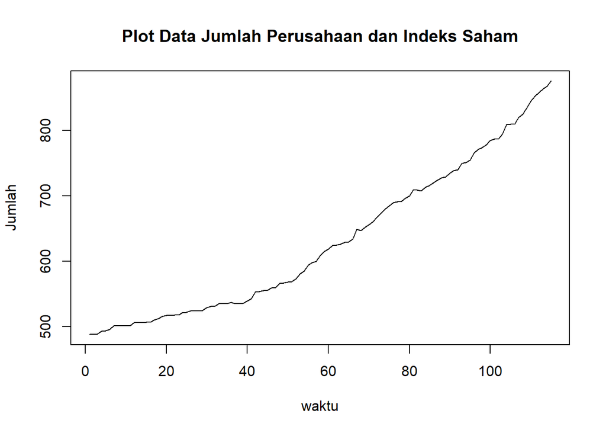

```r
plot.ts(dataa, lty=1, xlab="waktu", ylab="Jumlah", main="Plot Data Jumlah Perusahaan dan Indeks Saham")
```

Berdasarkan plot data deret waktu, terlihat bahwa data cenderung memiliki trend yang naik. Berdasarkan pola data, pembagian data latih dan data uji ditetapkan dengan proporsi 80%:20%.

#### Plot Data Latih

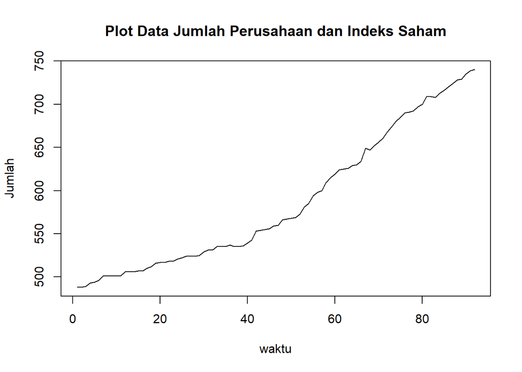

```r
datatrain<-dataa[1:92]
traints<-ts(datatrain)
plot.ts(traints, lty=1, xlab="waktu", ylab="Jumlah", main="Plot Data Jumlah Perusahaan dan Indeks Saham")
```

Berdasarkan plot data deret waktu pada data latih, terlihat bahwa data cenderung memiliki trend yang naik dan cenderung tidak bergerak pada nilai tengah tertentu. Hal ini mengindikasikan bahwa data tidak stasioner dalam rataan.

#### Plot Data Uji

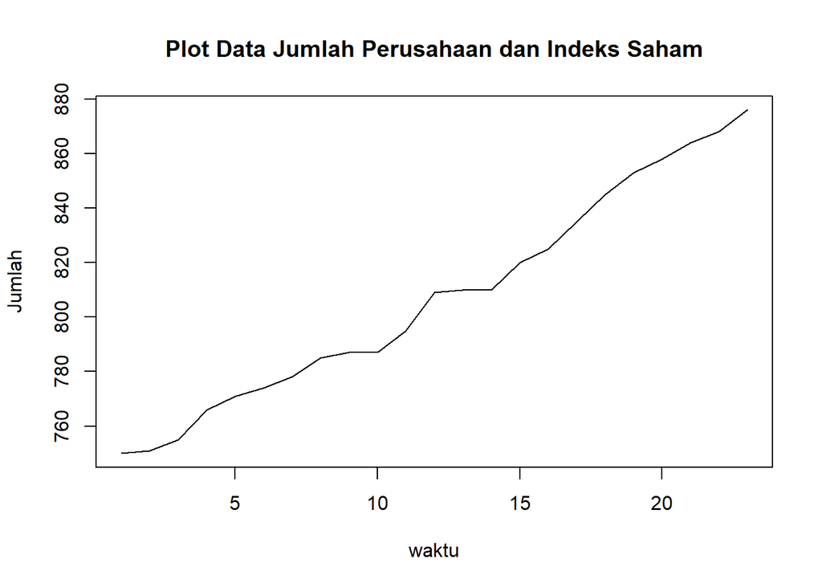

```r
datatest<-dataa[93:115]
testts<-ts(datatest)
plot.ts(testts, lty=1, xlab="waktu", ylab="Jumlah", main="Plot Data Jumlah Perusahaan dan Indeks Saham")
```

### Uji Stasioneritas Data

#### Plot ACF

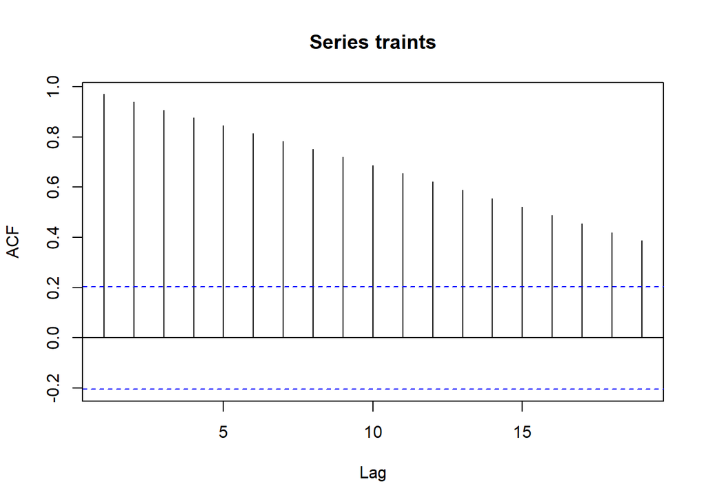

```r
acf(traints)
```

Berdasarkan plot ACF, terlihat bahwa plot ACF data menurun secara perlahan (*tails of slowly*). Hal ini juga menjadi indikasi bahwa data tidak stasioner dalam rataan

#### Uji ADF

```r
tseries::adf.test(traints)
```

```
##
##  Augmented Dickey-Fuller Test
##
## data:  traints
## Dickey-Fuller = -1.4152, Lag order = 4, p-value = 0.8173
## alternative hypothesis: stationary
```

$H_0$ : Data tidak stasioner dalam rataan

$H_1$ : Data stasioner dalam rataan

Berdasarkan uji ADF tersebut, didapat *p-value* sebesar 0.8173 yang lebih besar dari taraf nyata 5% sehingga tak tolak $H_0$ dan menandakan bahwa data tidak stasioner dalam rataan. Hal ini sesuai dengan hasil eksplorasi menggunakan plot time series dan plot ACF, sehingga ketidakstasioneran model kedepannya harus ditangani

#### Plot Box-Cox

```r
index <- seq(1:92)
bc = boxcox(traints~index, lambda = seq(-5,-2,by=1))
```

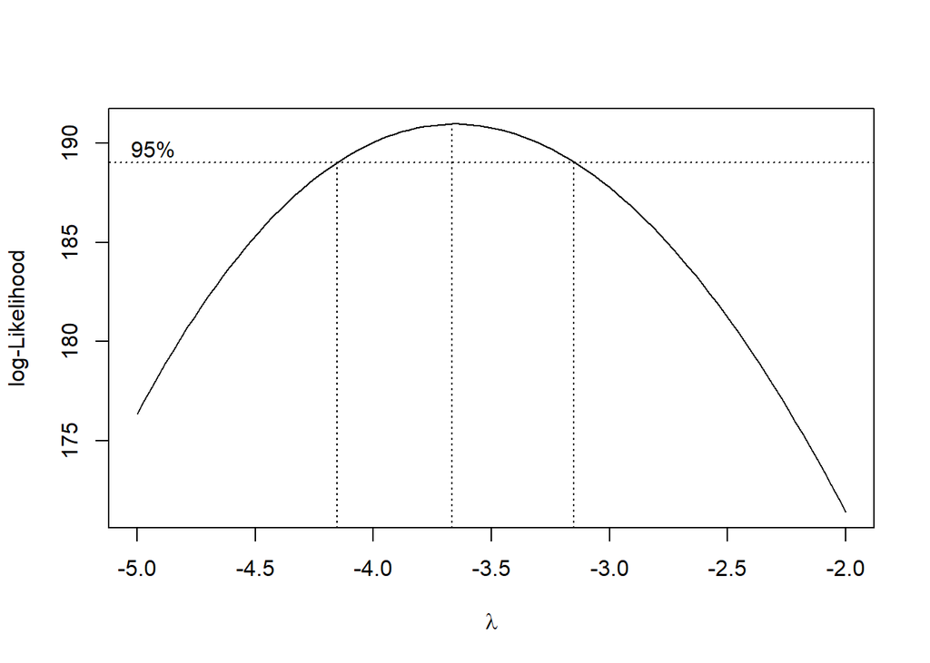

```r
#Nilai Rounded Lambda
lambda <- bc$x[which.max(bc$y)]
lambda
```

```
## [1] -3.666667
```

```r
#SK
bc$x[bc$y > max(bc$y) - 1/2 * qchisq(.95,1)]
```

```
##  [1] -4.151515 -4.121212 -4.090909 -4.060606 -4.030303 -4.000000 -3.969697
##  [8] -3.939394 -3.909091 -3.878788 -3.848485 -3.818182 -3.787879 -3.757576
## [15] -3.727273 -3.696970 -3.666667 -3.636364 -3.606061 -3.575758 -3.545455
## [22] -3.515152 -3.484848 -3.454545 -3.424242 -3.393939 -3.363636 -3.333333
## [29] -3.303030 -3.272727 -3.242424 -3.212121 -3.181818 -3.151515
```

Plot Boxcox menunjukkan nilai *rounded value* ($\lambda$) optimum sebesar **-3.67** dan pada selang kepercayaan 95% nilai memiliki batas bawah **-4.15** dan batas atas **-3.15**. Selang tersebut tidak memuat nilai satu sehingga dapat dikatakan bahwa data bangkitan tidak stasioner dalam ragam.

### Penanganan Ketidakstasioneran Data

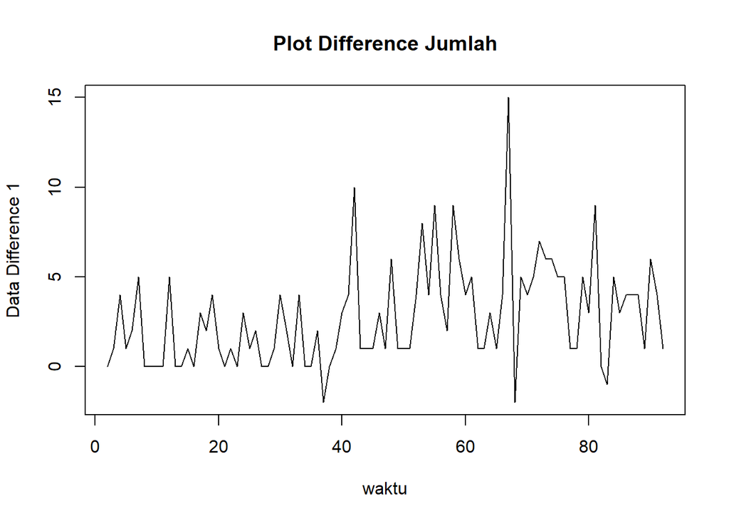

```r
train.diff<-diff(traints,differences = 1)
plot.ts(train.diff, lty=1, xlab="waktu", ylab="Data Difference 1", main="Plot Difference Jumlah")
```

Berdasarkan plot data deret waktu, terlihat bahwa data sudah stasioner dalam rataan ditandai dengan data bergerak pada nilai tengah tertentu (tidak terdapat trend ataupun musiman pada data)

#### Plot ACF

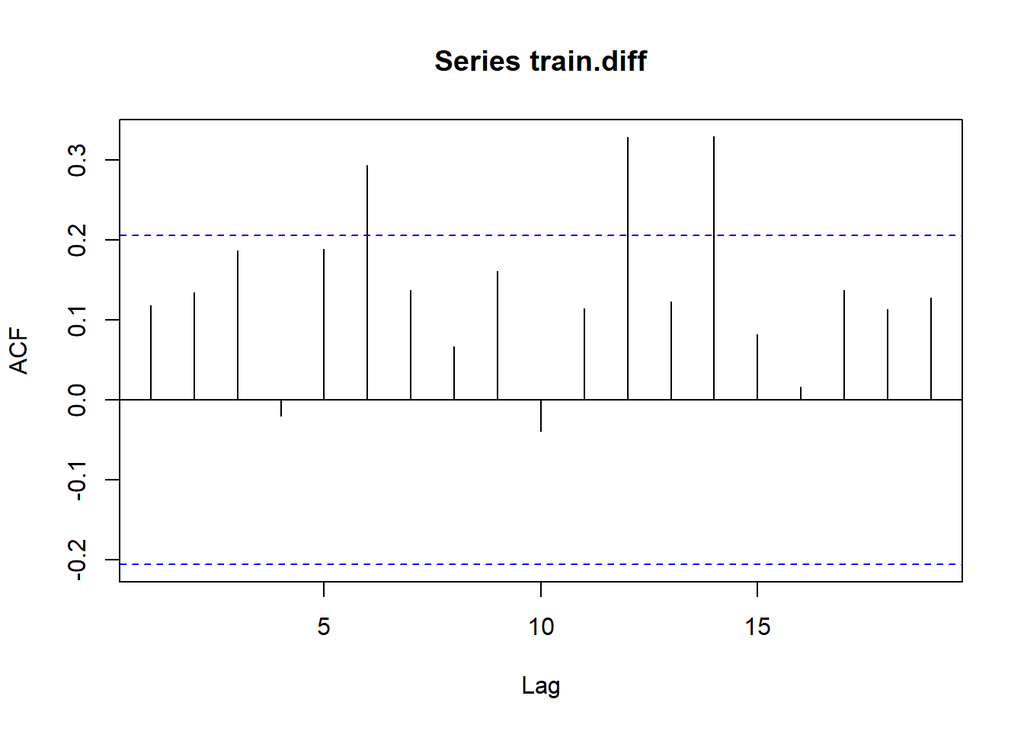

```r
acf(train.diff)
```

Berdasarkan plot tersebut, terlihat bahwa plot ACF cuts off pada lag ke 6. Hal ini menandakan data sudah stasioner dalam rataan dan ketidakstasioneran data telah berhasil tertangani.

#### Uji ADF

```r
tseries::adf.test(train.diff)
```

```
##
##  Augmented Dickey-Fuller Test
##
## data:  train.diff
## Dickey-Fuller = -4.071, Lag order = 4, p-value = 0.01
## alternative hypothesis: stationary
```

$H_0$ : Data tidak stasioner dalam rataan

$H_1$ : Data stasioner dalam rataan

Berdasarkan uji ADF tersebut, didapat *p-value* sebesar 0.01 yang lebih kecil dari taraf nyata 5% sehingga tolak $H_0$ atau data stasioner dalam rataan. Hal ini sesuai dengan hasil eksplorasi menggunakan plot time series dan plot ACF, sehingga dalam hal ini ketidakstasioneran data sudah berhasil ditangani dan dapat dilanjutkan ke pemodelan

### Identifikasi Model

#### Plot ACF

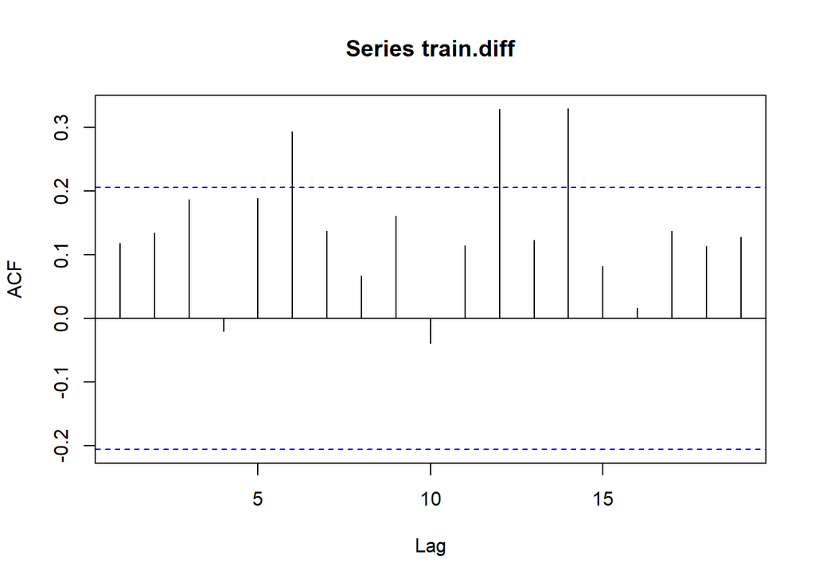

```r
acf(train.diff)
```

Berdasarkan plot tersebut, terlihat bahwa plot ACF cenderung *cuts off* pada lag ke 6, sehingga jika plot PACF dianggap *tails off*, maka model tentatifnya adalah ARIMA(0,1,6).

#### Plot PACF

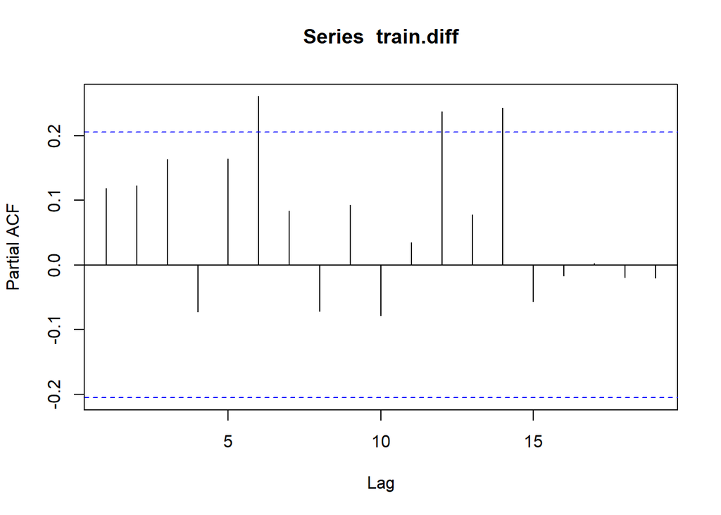

```r
pacf(train.diff)
```

Berdasarkan plot tersebut, terlihat bahwa plot PACF cenderung *cuts off* pada lag ke 6, sehingga jika plot ACF dianggap *tails off*, maka model tentatifnya adalah ARIMA(6,1,0).

Jika baik plot ACF maupun plot PACF keduanya dianggap tails of, maka model yang terbentuk adalah ARIMA(6,1,6)

#### Plot EACF

```r
eacf(train.diff)
```

```
## AR/MA
##   0 1 2 3 4 5 6 7 8 9 10 11 12 13
## 0 o o o o o x o o o o o  x  o  x
## 1 x o o o o o o o o o o  x  o  x
## 2 x o o o o o o o o o o  o  o  x
## 3 x x x o o o o o o o o  o  o  x
## 4 x o x x o o o o o o o  o  o  x
## 5 x x o o o o o o o o o  o  o  x
## 6 x x o o x x o o o o o  o  o  x
## 7 x o o o o x o o o o o  o  o  x
```

Identifikasi model menggunakan plot EACF dilakukan dengan melihat ujung segitiga pada pola segitiga nol. Dalam hal ini model tentatif yang terbentuk adalah ARIMA(1,1,1), ARIMA(2,1,2), ARIMA(3,1,3), dan ARIMA(4,1,4).

### Pendugaan Parameter Model Tentatif

#### ARIMA(0,1,6)

```r
model1.da=Arima(train.diff, order=c(0,1,6),method="ML")
summary(model1.da) #AIC=446.33
```

```
## Series: train.diff
## ARIMA(0,1,6)
##
## Coefficients:
##           ma1     ma2      ma3      ma4     ma5     ma6
##       -0.9682  0.0301  -0.0452  -0.2436  0.2985  0.0655
## s.e.   0.1075  0.1501   0.1493   0.1274  0.1574  0.1254
##
## sigma^2 = 7.41:  log likelihood = -216.17
## AIC=446.33   AICc=447.7   BIC=463.83
##
## Training set error measures:
##                     ME     RMSE      MAE  MPE MAPE      MASE         ACF1
## Training set 0.1231008 2.615326 1.894941 -Inf  Inf 0.7076543 -0.007235895
```

```r
lmtest::coeftest(model1.da) #terdapat parameter tidak signifikan
```

```
##
## z test of coefficients:
##
##      Estimate Std. Error z value Pr(>|z|)
## ma1 -0.968218   0.107538 -9.0035  < 2e-16 ***
## ma2  0.030097   0.150076  0.2005  0.84105
## ma3 -0.045217   0.149302 -0.3029  0.76200
## ma4 -0.243580   0.127412 -1.9118  0.05591 .
## ma5  0.298540   0.157421  1.8964  0.05790 .
## ma6  0.065544   0.125407  0.5227  0.60122
## ---
## Signif. codes:  0 '***' 0.001 '**' 0.01 '*' 0.05 '.' 0.1 ' ' 1
```

#### ARIMA(6,1,0)

```r
model2.da=Arima(train.diff, order=c(6,1,0),method="ML")
summary(model2.da) #AIC=449.42
```

```
## Series: train.diff
## ARIMA(6,1,0)
##
## Coefficients:
##           ar1      ar2      ar3      ar4      ar5      ar6
##       -0.9076  -0.7398  -0.5493  -0.6244  -0.4395  -0.1233
## s.e.   0.1054   0.1352   0.1398   0.1377   0.1327   0.1044
##
## sigma^2 = 7.772:  log likelihood = -217.71
## AIC=449.42   AICc=450.78   BIC=466.92
##
## Training set error measures:
##                     ME     RMSE      MAE MPE MAPE      MASE          ACF1
## Training set 0.1099648 2.678464 1.932162 NaN  Inf 0.7215542 -0.0005180539
```

```r
lmtest::coeftest(model2.da) #terdapat parameter tidak signifikan
```

```
##
## z test of coefficients:
##
##     Estimate Std. Error z value  Pr(>|z|)
## ar1 -0.90755    0.10537 -8.6134 < 2.2e-16 ***
## ar2 -0.73976    0.13516 -5.4731 4.421e-08 ***
## ar3 -0.54934    0.13977 -3.9303 8.485e-05 ***
## ar4 -0.62441    0.13767 -4.5354 5.750e-06 ***
## ar5 -0.43946    0.13270 -3.3117 0.0009272 ***
## ar6 -0.12330    0.10437 -1.1814 0.2374422
## ---
## Signif. codes:  0 '***' 0.001 '**' 0.01 '*' 0.05 '.' 0.1 ' ' 1
```

#### ARIMA(6,1,6)

```r
model3.da=Arima(train.diff, order=c(6,1,6),method="ML")
summary(model3.da) #AIC=450.88
```

```
## Series: train.diff
## ARIMA(6,1,6)
##
## Coefficients:
##           ar1      ar2      ar3      ar4      ar5     ar6      ma1      ma2
##       -0.4711  -0.3134  -0.5131  -0.5847  -0.6260  0.1416  -0.5096  -0.0647
## s.e.   0.2560   0.2029   0.1079   0.2071   0.2061  0.1412   0.2470   0.2759
##          ma3      ma4     ma5      ma6
##       0.3798  -0.1031  0.3149  -0.6470
## s.e.  0.1967   0.2805  0.2546   0.1499
##
## sigma^2 = 7.016:  log likelihood = -212.44
## AIC=450.88   AICc=455.66   BIC=483.37
##
## Training set error measures:
##                     ME     RMSE      MAE  MPE MAPE      MASE        ACF1
## Training set 0.2220288 2.452281 1.780326 -Inf  Inf 0.6648519 -0.01577086
```

```r
lmtest::coeftest(model3.da) #terdapat parameter tidak signifikan
```

```
##
## z test of coefficients:
##
##      Estimate Std. Error z value  Pr(>|z|)
## ar1 -0.471051   0.256023 -1.8399  0.065787 .
## ar2 -0.313397   0.202891 -1.5447  0.122430
## ar3 -0.513080   0.107924 -4.7541 1.993e-06 ***
## ar4 -0.584684   0.207108 -2.8231  0.004756 **
## ar5 -0.626030   0.206108 -3.0374  0.002386 **
## ar6  0.141588   0.141223  1.0026  0.316062
## ma1 -0.509637   0.246976 -2.0635  0.039065 *
## ma2 -0.064739   0.275896 -0.2347  0.814480
## ma3  0.379827   0.196655  1.9314  0.053428 .
## ma4 -0.103117   0.280510 -0.3676  0.713167
## ma5  0.314947   0.254591  1.2371  0.216060
## ma6 -0.647004   0.149852 -4.3176 1.577e-05 ***
## ---
## Signif. codes:  0 '***' 0.001 '**' 0.01 '*' 0.05 '.' 0.1 ' ' 1
```

#### ARIMA(1,1,1)

```r
model4.da=Arima(train.diff, order=c(1,1,1),method="ML")
summary(model4.da) #AIC=445.3
```

```
## Series: train.diff
## ARIMA(1,1,1)
##
## Coefficients:
##           ar1      ma1
##       -0.0547  -0.8975
## s.e.   0.1132   0.0463
##
## sigma^2 = 7.74:  log likelihood = -219.65
## AIC=445.3   AICc=445.58   BIC=452.8
##
## Training set error measures:
##                     ME     RMSE      MAE  MPE MAPE     MASE      ACF1
## Training set 0.2493247 2.735864 1.961344 -Inf  Inf 0.732452 -0.017723
```

```r
lmtest::coeftest(model4.da) #terdapat parameter tidak signifikan
```

```
##
## z test of coefficients:
##
##      Estimate Std. Error  z value Pr(>|z|)
## ar1 -0.054657   0.113193  -0.4829   0.6292
## ma1 -0.897499   0.046337 -19.3689   <2e-16 ***
## ---
## Signif. codes:  0 '***' 0.001 '**' 0.01 '*' 0.05 '.' 0.1 ' ' 1
```

#### ARIMA(2,1,2)

```r
model5.da=Arima(train.diff, order=c(2,1,2),method="ML")
summary(model5.da) #AIC=448.26
```

```
## Series: train.diff
## ARIMA(2,1,2)
##
## Coefficients:
##           ar1      ar2      ma1      ma2
##       -0.8078  -0.1178  -0.1406  -0.6673
## s.e.   0.2994   0.1144   0.2869   0.2626
##
## sigma^2 = 7.825:  log likelihood = -219.13
## AIC=448.26   AICc=448.97   BIC=460.76
##
## Training set error measures:
##                    ME     RMSE      MAE  MPE MAPE      MASE         ACF1
## Training set 0.240377 2.719393 1.969891 -Inf  Inf 0.7356438 -0.009533494
```

```r
lmtest::coeftest(model5.da) #terdapat parameter tidak signifikan
```

```
##
## z test of coefficients:
##
##     Estimate Std. Error z value Pr(>|z|)
## ar1 -0.80778    0.29942 -2.6978  0.00698 **
## ar2 -0.11775    0.11440 -1.0293  0.30334
## ma1 -0.14061    0.28690 -0.4901  0.62406
## ma2 -0.66729    0.26263 -2.5408  0.01106 *
## ---
## Signif. codes:  0 '***' 0.001 '**' 0.01 '*' 0.05 '.' 0.1 ' ' 1
```

#### ARIMA(3,1,3)

```r
model6.da=Arima(train.diff, order=c(3,1,3),method="ML")
summary(model6.da) #AIC=447.67
```

```
## Series: train.diff
## ARIMA(3,1,3)
##
## Coefficients:
##           ar1      ar2     ar3      ma1     ma2      ma3
##       -0.8139  -0.7262  0.1259  -0.1144  0.0482  -0.6988
## s.e.   0.2954   0.2436  0.1373   0.2879  0.1983   0.1341
##
## sigma^2 = 7.592:  log likelihood = -216.84
## AIC=447.67   AICc=449.04   BIC=465.17
##
## Training set error measures:
##                     ME     RMSE      MAE  MPE MAPE      MASE         ACF1
## Training set 0.2540436 2.647295 1.921159 -Inf  Inf 0.7174452 -0.007727489
```

```r
lmtest::coeftest(model6.da) #terdapat parameter tidak signifikan
```

```
##
## z test of coefficients:
##
##      Estimate Std. Error z value  Pr(>|z|)
## ar1 -0.813867   0.295381 -2.7553  0.005864 **
## ar2 -0.726172   0.243604 -2.9810  0.002873 **
## ar3  0.125943   0.137259  0.9176  0.358851
## ma1 -0.114376   0.287857 -0.3973  0.691121
## ma2  0.048246   0.198347  0.2432  0.807820
## ma3 -0.698840   0.134115 -5.2108 1.881e-07 ***
## ---
## Signif. codes:  0 '***' 0.001 '**' 0.01 '*' 0.05 '.' 0.1 ' ' 1
```

#### ARIMA(4,1,4)

```r
model6.da=Arima(train.diff, order=c(4,1,4),method="ML")
summary(model6.da) #AIC=446.45
```

```
## Series: train.diff
## ARIMA(4,1,4)
##
## Coefficients:
##          ar1      ar2     ar3      ar4      ma1     ma2      ma3     ma4
##       0.2715  -0.1043  0.6445  -0.2716  -1.2633  0.4289  -0.7718  0.6940
## s.e.  0.2088   0.1986  0.1420   0.1122   0.2101  0.3955   0.3371  0.1584
##
## sigma^2 = 7.179:  log likelihood = -214.22
## AIC=446.45   AICc=448.7   BIC=468.94
##
## Training set error measures:
##                      ME     RMSE      MAE  MPE MAPE      MASE         ACF1
## Training set 0.09349847 2.543423 1.879405 -Inf  Inf 0.7018526 -0.005509274
```

```r
lmtest::coeftest(model6.da) #terdapat parameter tidak signifikan
```

```
##
## z test of coefficients:
##
##     Estimate Std. Error z value  Pr(>|z|)
## ar1  0.27148    0.20880  1.3002   0.19354
## ar2 -0.10426    0.19859 -0.5250   0.59958
## ar3  0.64454    0.14199  4.5394 5.642e-06 ***
## ar4 -0.27157    0.11221 -2.4203   0.01551 *
## ma1 -1.26333    0.21007 -6.0139 1.811e-09 ***
## ma2  0.42888    0.39546  1.0845   0.27813
## ma3 -0.77179    0.33708 -2.2896   0.02204 *
## ma4  0.69398    0.15839  4.3816 1.178e-05 ***
## ---
## Signif. codes:  0 '***' 0.001 '**' 0.01 '*' 0.05 '.' 0.1 ' ' 1
```

### Analisis Sisaan

Model terbaik hasil identifikasi kemudian dicek asumsi sisaannya. Sisaan model ARIMA harus memenuhi asumsi normalitas, kebebasan sisaan, dan kehomogenan ragam. Diagnostik model dilakukan secara eksplorasi dan uji formal.

#### Eksplorasi Sisaan

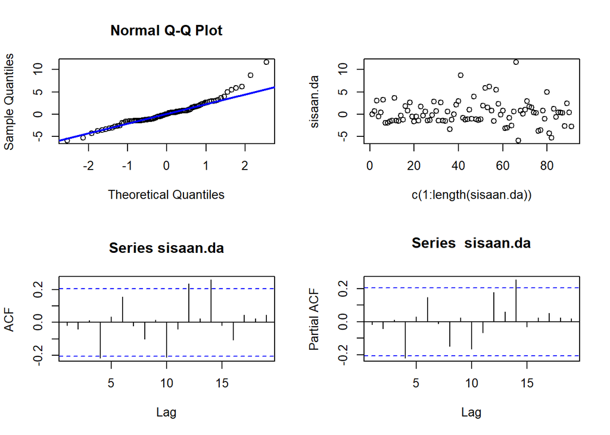

```r
#Eksplorasi
sisaan.da <- model4.da$residuals
par(mfrow=c(2,2))
qqnorm(sisaan.da)
qqline(sisaan.da, col = "blue", lwd = 2)
plot(c(1:length(sisaan.da)),sisaan.da)
acf(sisaan.da)
pacf(sisaan.da)
```

```r
par(mfrow = c(1,1))
```

Berdasarkan plot kuantil-kuantil normal, secara eksplorasi ditunjukkan sisaan tidak menyebar normal ditandai dengan titik titik yang cenderung tidak mengikuti garis $45^{\circ}$. Kemudian dapat dilihat juga lebar pita sisaan yang cenderung tidak sama menandakan bahwa sisaan memiliki ragam yang heterogen. Plot ACF dan PACF sisaan ARIMA(1,1,1) terlihat signifikan pada lag ke-4 yang menandakan tidak saling bebas. Kondisi ini akan diuji lebih lanjut dengan uji formal.

#### Uji Formal

```r
#1) Sisaan Menyebar Normal
ks.test(sisaan.da,"pnorm")  #tak tolak H0 > sisaan menyebar normal
```

```
##
##  Exact one-sample Kolmogorov-Smirnov test
##
## data:  sisaan.da
## D = 0.22311, p-value = 0.0001846
## alternative hypothesis: two-sided
```

Selain dengan eksplorasi, asumsi tersebut dapat diuji menggunakan uji formal. Pada tahapan ini uji formal yang digunakan untuk normalitas adalah uji Kolmogorov-Smirnov (KS). Hipotesis pada uji KS adalah sebagai berikut.

$H_0$ : Sisaan menyebar normal

$H_1$ : Sisaan tidak menyebar normal

Berdasarkan uji KS tersebut, didapat *p-value* sebesar 0.00 yang kurang dari taraf nyata 5% sehingga tolak $H_0$ dan menandakan bahwa sisaan tidak menyebar normal. Hal ini sesuai dengan hasil eksplorasi menggunakan plot kuantil-kuantil normal.

```r
#2) Sisaan saling bebas/tidak ada autokorelasi
Box.test(sisaan.da, type = "Ljung")  #tak tolak H0 > sisaan saling bebas
```

```
##
##  Box-Ljung test
##
## data:  sisaan.da
## X-squared = 0.029536, df = 1, p-value = 0.8635
```

Selanjutnya akan dilakukan uji formal untuk kebebasan sisaan menggunakan uji Ljung-Box. Hipotesis yang digunakan adalah sebagai berikut.

$H_0$ : Sisaan saling bebas

$H_1$ : Sisaan tidak tidak saling bebas

Berdasarkan uji Ljung-Box tersebut, didapat *p-value* sebesar 0.8635 yang lebih besar dari taraf nyata 5% sehingga tak tolak $H_0$ dan menandakan bahwa sisaan saling bebas. Hal ini berbeda dengan eksplorasi.

```r
#3) Sisaan homogen
Box.test((sisaan.da)^2, type = "Ljung")  #tak tolak H0 > sisaan homogen
```

```
##
##  Box-Ljung test
##
## data:  (sisaan.da)^2
## X-squared = 0.93987, df = 1, p-value = 0.3323
```

Hipotesis yang digunakan untuk uji kehomogenan ragam adalah sebagai berikut.

$H_0$ : Ragam sisaan homogen

$H_1$ : Ragam sisaan tidak homogen

Berdasarkan uji Ljung-Box terhadap sisaan kuadrat tersebut, didapat *p-value* sebesar 0.3323 yang lebih dari taraf nyata 5% sehingga tak tolak $H_0$ dan menandakan bahwa ragam sisaan homogen. Hal ini berbeda dengan eksplorasi.

```r
#4) Nilai tengah sisaan sama dengan nol
t.test(sisaan.da, mu = 0, conf.level = 0.95)  #tak tolak h0 > nilai tengah sisaan sama dengan 0
```

```
##
##  One Sample t-test
##
## data:  sisaan.da
## t = 0.86817, df = 90, p-value = 0.3876
## alternative hypothesis: true mean is not equal to 0
## 95 percent confidence interval:
##  -0.3212192  0.8198686
## sample estimates:
## mean of x
## 0.2493247
```

Terakhir, dengan uji-t, akan dicek apakah nilai tengah sisaan sama dengan nol. Hipotesis yang diujikan sebagai berikut.

$H_0$ : nilai tengah sisaan sama dengan 0

$H_1$ : nilai tengah sisaan tidak sama dengan 0

Berdasarkan uji-ttersebut, didapat *p-value* sebesar 0.3876 yang lebih besar dari taraf nyata 5% sehingga tak tolak $H_0$ dan menandakan bahwa nilai tengah sisaan sama dengan nol.

### Peramalan

Peramalan dilakukan menggunakan fungsi `forecast()` . Contoh peramalan berikut ini dilakukan untuk 30 hari ke depan.

```r
#---FORECAST---#
ramalan.da <- forecast::forecast(model4.da, h = 30)
ramalan.da
```

```
##     Point Forecast       Lo 80    Hi 80     Lo 95    Hi 95
##  93       3.608558  0.04314371 7.173972 -1.844273 9.061388
##  94       3.465982 -0.10351044 7.035475 -1.993086 8.925050
##  95       3.473775 -0.11343977 7.060989 -2.012396 8.959946
##  96       3.473349 -0.13051287 7.077211 -2.038282 8.984980
##  97       3.473372 -0.14711322 7.093858 -2.063682 9.010427
##  98       3.473371 -0.16365927 7.110401 -2.088987 9.035729
##  99       3.473371 -0.18012920 7.126871 -2.114175 9.060917
## 100       3.473371 -0.19652529 7.143267 -2.139251 9.085993
## 101       3.473371 -0.21284845 7.159590 -2.164215 9.110957
## 102       3.473371 -0.22909964 7.175842 -2.189069 9.135811
## 103       3.473371 -0.24527981 7.192022 -2.213815 9.160557
## 104       3.473371 -0.26138989 7.208132 -2.238453 9.185195
## 105       3.473371 -0.27743077 7.224173 -2.262985 9.209727
## 106       3.473371 -0.29340334 7.240145 -2.287413 9.234155
```

[output cut: 16 more lines]

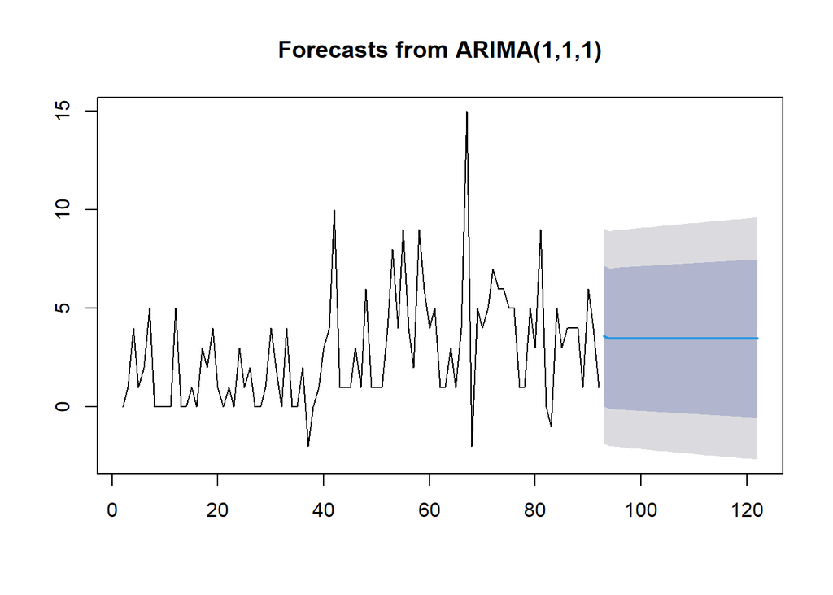

```r
data.ramalan.da <- ramalan.da$mean
plot(ramalan.da)
```

Berdasarkan hasil plot ramalan di atas, dapat dilihat bahwa ramalan ARIMA(1,1,1) cenderung stabil hingga akhir periode. Selanjutnya, dapat dicari nilai akurasi antara hasil ramalan dengan data uji sebagai berikut.

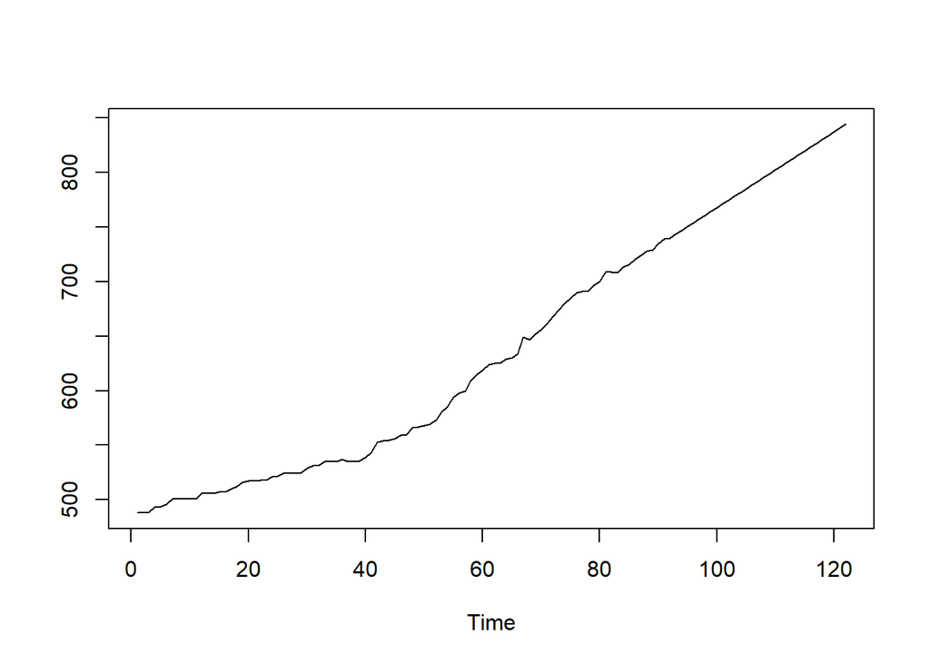

```r
pt_1 <- traints[92] #nilai akhir data latih
hasil.forc.Diff <- data.ramalan.da
hasil <- diffinv(hasil.forc.Diff, differences = 1) + pt_1
#has.1 sama hasilnta dengan: cumsum(c(pt_1,hasil.forc.Diff))
ts.plot(traints,hasil)
```

```r
perbandingan.da<-matrix(data=c(head(testts, n=30), hasil[-1]),
                     nrow = 30, ncol = 2)
colnames(perbandingan.da)<-c("Aktual","Hasil Forecast")
perbandingan.da
```

```
##         Aktual Hasil Forecast
##  [1,] 750.0000       767.9151
##  [2,] 751.0000       771.3885
##  [3,] 755.0000       774.8619
##  [4,] 766.0000       778.3353
##  [5,] 771.0000       781.8086
##  [6,] 774.0000       785.2820
##  [7,] 778.0000       788.7554
##  [8,] 785.0000       792.2287
##  [9,] 787.0000       795.7021
## [10,] 787.0000       799.1755
## [11,] 795.0000       802.6489
## [12,] 809.0000       806.1222
## [13,] 810.0000       809.5956
## [14,] 810.0000       813.0690
```

[output cut: 16 more lines]

```r
accuracy(ts(hasil[-1]), head(testts, n=30))
```

```
##                ME   RMSE      MAE     MPE    MAPE      ACF1 Theil's U
## Test set 25.66934 30.318 25.66934 3.09269 3.09269 0.8569423  4.346598
```